# crmPack: Object-oriented implementation of CRM designs

Ziwei Liao, Daniel Sabanés Bové

02 January 2019

This short vignette shall introduce into the usage of the package `crmPack`. Hopefully it makes it easy for you to set up your own CRM.

If you have any questions or feedback concerning the package, please write an email to the package maintainer: daniel.sabanes_bove@rconis.com.

Thank you very much in advance!

# 1 Installation

Many models in `crmPack` rely on [JAGS](https://mcmc-jags.sourceforge.io/) (please click on the link for going to the webpage of the project) for the internal MCMC computations. WinBUGS is not required or supported anymore.

# 2 Getting started

Before being able to run anything, you have to load the package with

```r
library(crmPack)
library(data.tree)
```

For browsing the help pages for the package, it is easiest to start the web browser interface with

```r
crmPackHelp()
```

This gives you the list of all help pages available for the package. The whole R-package is built in a modular form, by using S4 classes and methods. Please have a look at the help page “Methods” to read an introduction into the S4 object framework of R, by typing `?Methods` in the R console. In the next sections we will therefore go one by one through the important building blocks (S4 classes and corresponding methods) of CRM designs with `crmPack`.

# 3 Data

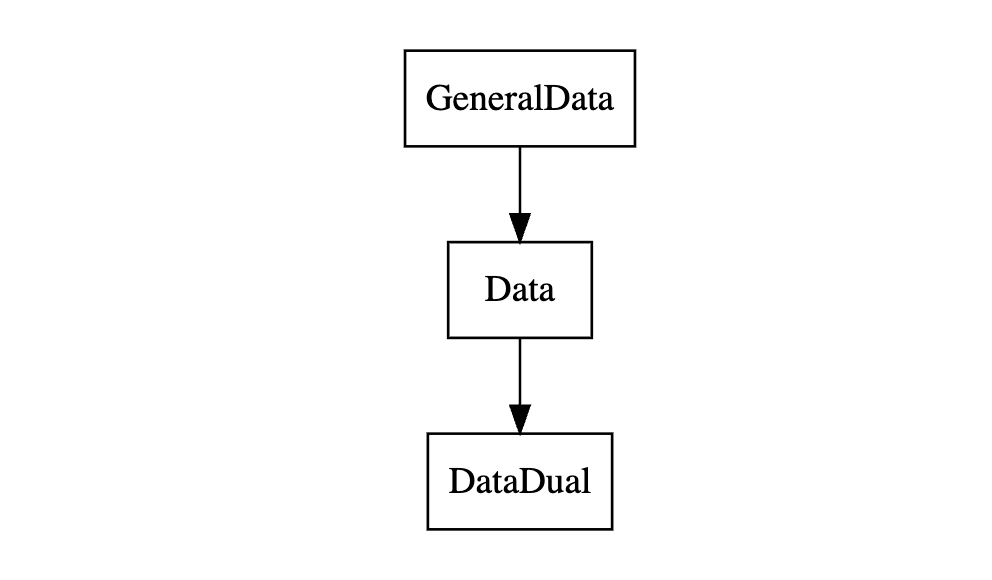

Data classes structure

```r
df <- data.frame(
  pathString = c(
    "GeneralData/Data/DataDual"
  )
)

tree <- as.Node(df)
SetNodeStyle(tree, shape = "box")
plot(tree)
```

We have three data classes for this package. The parent class is the `GeneralData` class. The `Data` class is inheriting from the `GeneralData` class and the `DataDual` class is inheriting from the `Data` class. Inheritance means that the subclass has all the slots (attributes) of the parent class, but can also have additional slots. Methods that work on the parent class also work the same way on the subclass, unless a specialized method for the subclass has been defined.

First, we will set up the data set. If you are at the beginning of a trial, no observations will be available. Then we can define an empty data set, for example:

```r
emptydata <- Data(
  doseGrid =
    c(
      0.1, 0.5, 1.5, 3, 6,
      seq(from = 10, to = 80, by = 2)
    )
)
```

The `R`-package `crmPack` uses the S4 class system for implementation of the dose-escalation designs. There is the convention that class initialization functions have the same name as the class, and all class names are capitalized. Note that in order to create this `Data` object, we use the initialization function of the same name, and give it as parameters the contents of the object to be constructed. At least the `doseGrid` parameter, which contains all possible dose levels to be potentially used in the trial, must be specified in a call of the `Data()` initialization function.

If you are in the middle of a trial and you would like to recommend the next dose, then you have data from the previous patients for input into the model. This data can also be captured in a `Data` object. For example:

```r
data <- Data(
  x = c(0.1, 0.5, 1.5, 3, 6, 10, 10, 10),
  y = c(0, 0, 0, 0, 0, 0, 1, 0),
  cohort = c(0, 1, 2, 3, 4, 5, 5, 5),
  doseGrid =
    c(
      0.1, 0.5, 1.5, 3, 6,
      seq(from = 10, to = 80, by = 2)
    )
)
```

Most important are `x` (the doses) and `y` (the DLTs, `0` for no DLT and `1` for DLT), and we are using the same dose grid `doseGrid` as before. All computations are using the dose grid specified in the `Data` object. So for example, except for patient number 7, all patients were free of DLTs.

Again, you can find out the details in the help page `Data-class`. Note that you have received a warning here, because you did not specify the patient IDs – however, automatic ones just indexing the patients have been created for you:

```r
data@ID
```

```
#> [1] 1 2 3 4 5 6 7 8
```

You can get a visual summary of the data by applying `plot` to the object:

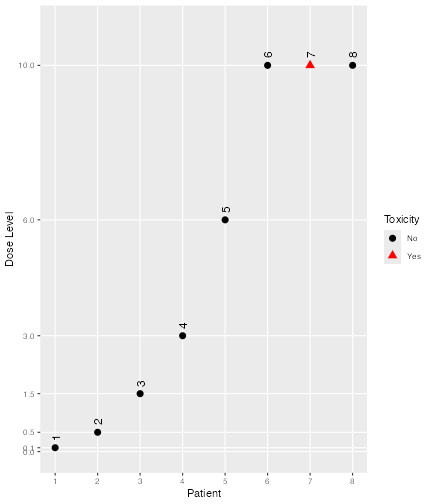

```r
print(plot(data))
```

> Note that for all `plot` calls in this vignette, you can leave away the wrapping `print` function call if you are working interactively with `R`. It is only because of the `knitr` production of this vignette that the `print` statement is needed.

# 4 Structure of the model class

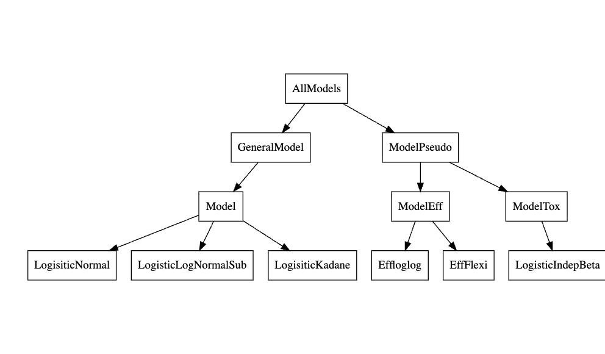

Model classes structure

# 5 Model setup

## 5.1 Logistic model with bivariate (log) normal prior

First, we will show an example of setting up of a model inheriting from the `model` and `GeneralModel` classes, the logistic normal model. You can click on the corresponding help page `LogisticLogNormal-class` as background information for the next steps.

With the following command, we create a new model of class `LogisticLogNormal`, with certain mean and covariance prior parameters and reference dose:

```r
model <- LogisticLogNormal(
  mean = c(-0.85, 1),
  cov =
    matrix(c(1, -0.5, -0.5, 1),
      nrow = 2
    ),
  ref_dose = 56
)
```

We can query the class that an object belongs to with the `class` function:

```r
class(model)
```

```
#> [1] "LogisticLogNormal"
#> attr(,"package")
#> [1] "crmPack"
```

We can look in detail at the structure of `model` as follows:

```r
str(model)
```

```
#> Formal class 'LogisticLogNormal' [package "crmPack"] with 9 slots
#>   ..@ params         :Formal class 'ModelParamsNormal' [package "crmPack"] with 3 slots
#>   .. .. ..@ mean: num [1:2] -0.85 1
#>   .. .. ..@ cov : num [1:2, 1:2] 1 -0.5 -0.5 1
#>   .. .. ..@ prec: num [1:2, 1:2] 1.333 0.667 0.667 1.333
#>   ..@ ref_dose       :Formal class 'positive_number' [package "crmPack"] with 1 slot
#>   .. .. ..@ .Data: num 56
#>   ..@ datamodel      :function ()
#>   .. ..- attr(*, "srcref")= 'srcref' int [1:8] 290 17 295 5 17 5 290 295
#>   .. .. ..- attr(*, "srcfile")=Classes 'srcfilecopy', 'srcfile' <environment: 0x753f7d1150>
#>   ..@ priormodel     :function ()
#>   .. ..- attr(*, "srcref")= 'srcref' int [1:8] 146 18 150 5 18 5 146 150
#>   .. .. ..- attr(*, "srcfile")=Classes 'srcfilecopy', 'srcfile' <environment: 0x753f7d1150>
#>   ..@ modelspecs     :function (from_prior)
#>   .. ..- attr(*, "srcref")= 'srcref' int [1:8] 151 18 157 5 18 5 151 157
#>   .. .. ..- attr(*, "srcfile")=Classes 'srcfilecopy', 'srcfile' <environment: 0x753f7d1150>
#>   ..@ init           :function ()
#>   .. ..- attr(*, "srcref")= 'srcref' int [1:8] 158 12 160 5 12 5 158 160
#>   .. .. ..- attr(*, "srcfile")=Classes 'srcfilecopy', 'srcfile' <environment: 0x753f7d1150>
#>   ..@ datanames      : chr [1:3] "nObs" "y" "x"
#>   ..@ datanames_prior: chr(0)
#>   ..@ sample         : chr [1:2] "alpha0" "alpha1"
```

We see that the object has 9 slots, and their names. These can be accessed with the `@` operator (similarly as for lists the `$` operator), for example we can extract the `ref_dose` slot:

```r
model@ref_dose
```

```
#> An object of class "positive_number"
#> [1] 56
```

You can find out yourself about the other slots, by looking at the help page for `Model-class` in the help browser, because all univariate models with JAGS specification are just special cases (subclasses) of the `model` class. In the `Model-class` help page, you also find out that there are four additional specific model classes that are sub-classes of the `model` class, namely `LogisticLogNormalSub`, `LogisticNormal`, `LogisticKadane` and `DualEndpoint`.

Next, we will show an example of setting up a model of the `ModelPseudo` class, the `LogisticIndepBeta` model. More specifically, this is also a model in `ModelTox` class.

The `LogisticIndepBeta` model is a two-parameter logistic regression model to describe the relationship between the probability of the occurrence of DLT and its corresponding log dose levels. The model parameters are φ<sub>1</sub>, for the intercept and φ <sub>2</sub>, the slope. This is also a model for which its prior is expressed in form of pseudo data.

Here it is important that the data set has to be defined before defining any models from `ModelPseudo` class. This is to ensure we obtained the updated estimates for the model parameters using all currently available observations. Either an empty data set or a data set that contains all currently available observations is needed.

Therefore, let’s assume an empty data set is set up. For example, we will use 12 dose levels from 25 to 300 mg with increments of 25 mg. Then we have:

```r
emptydata <- Data(
  doseGrid =
    seq(from = 25, to = 300, by = 25)
)
data1 <- emptydata
```

Then we express our prior in form of pseudo data. The idea is as follows. First fix two dose level $d_{(-1)}$ and $d_{(0)}$, which are usually the lowest and the highest dose level, so here we choose 25 and 300 mg. Then we elicit from experts or clinicians the probability of the occurrence of DLT, $p_{(-1)}$ and $p_{(0)}$ at these two dose levels. That is, assuming $n_{(l)}$ subjects are treated at each of these two dose levels, $l=-1,0$, $t_{(l)}$ out of $n{(l)}$ subjects are expected to be observed with a DLT such that $p_{(l)} = t_{(l)}/n_{(l)}$. Let $\tilde{p}_{(l)}$ be the probability of the occurrence of a DLT at dose $l$ for dose $l=-1,0$. $\tilde{p}_{(l)}$ will follow independent Beta distributions and the joint probability density function of $p_{(l)}$ can be obtained. Therefore, this model is called `LogisticIndepBeta`. We expressed the prior as if we have some data (pseudo data) before the trial start. The prior modal estimates of φ<sub>1</sub> and φ<sub>2</sub>, which is also equivalent to the maximum likelihood estimators, can be obtained with the R function `glm`. Please refer to (Whitehead and Williamson 1998) for details about the form of the prior and posterior density of the model parameters φ<sub>1</sub> and φ<sub>2</sub>.

With the following commands, we create the model of class `LogisticIndepBeta`, with the prior specified in form of pseudo data.

```r
DLTmodel <- LogisticIndepBeta(
  binDLE = c(1.05, 1.8), DLEweights = c(3, 3),
  DLEdose = c(25, 300), data = data1
)
```

(Note that in some functions including this initialization function, DLE instead of DLT is used. In this vignette we use the unified abbreviation DLT throughout the text and variable names.)

Since the imaginary nature of the pseudo data, the value $t_l$ for the number of subjects observed with DLT can be non-integer values. In principle, $n_l$ can also be non-integer values.

Then we can look at the structure of this model:

```r
str(DLTmodel)
```

```
#> Formal class 'LogisticIndepBeta' [package "crmPack"] with 7 slots
#>   ..@ binDLE    : num [1:2] 1.05 1.8
#>   ..@ DLEdose   : num [1:2] 25 300
#>   ..@ DLEweights: int [1:2] 3 3
#>   ..@ phi1      : num -1.95
#>   ..@ phi2      : num 0.412
#>   ..@ Pcov      : num [1:2, 1:2] 10.05 -2.077 -2.077 0.462
#>   .. ..- attr(*, "dimnames")=List of 2
#>   .. .. ..$ : chr [1:2] "(Intercept)" "log(x)"
#>   .. .. ..$ : chr [1:2] "(Intercept)" "log(x)"
#>   ..@ data      :Formal class 'Data' [package "crmPack"] with 11 slots
#>   .. .. ..@ x         : num(0)
#>   .. .. ..@ y         : int(0)
#>   .. .. ..@ doseGrid  : num [1:12] 25 50 75 100 125 150 175 200 225 250 ...
#>   .. .. ..@ nGrid     : int 12
#>   .. .. ..@ xLevel    : int(0)
#>   .. .. ..@ placebo   : logi FALSE
#>   .. .. ..@ backfilled: logi(0)
#>   .. .. ..@ response  : int(0)
#>   .. .. ..@ ID        : int(0)
#>   .. .. ..@ cohort    : int(0)
#>   .. .. ..@ nObs      : int 0
```

```r
DLTmodel@phi1
```

```
#> [1] -1.946152
```

This gives the updated modal estimate of the intercept parameter φ<sub>1</sub>. Please find out other slots using the `@` operator and looking at the help page for `ModelPseudo`, `ModelTox` and `LogisticIndepBeta` classes.

## 5.2 Advanced model specification

There are a few further, advanced ways to specify a model object in `crmPack`.

First, a minimal informative prior (Neuenschwander et al. 2008) can be computed using the `MinimalInformative` function. The construction is based on the input of a minimal and a maximal dose, where certain ranges of DLT probabilities are deemed unlikely. A logistic function is then fitted through the corresponding points on the dose-toxicity plane in order to derive Beta distributions also for doses in-between. Finally these Beta distributions are approximated by a common `LogisticNormal` (or `LogisticLogNormal`) model. So the minimal informative construction avoids explicit specification of the prior parameters of the logistic regression model.

In our example, we could construct it as follows, assuming a minimal dose of 0.1 mg and a maximum dose of 100 mg:

```r
coarseGrid <- c(0.1, 10, 30, 60, 100)
minInfModel <- MinimalInformative(
  dosegrid = coarseGrid,
  refDose = 50,
  threshmin = 0.2,
  threshmax = 0.3,
  control =
    list(
      threshold.stop = 0.03,
      maxit = 200
    ),
  seed = 432
)
```

[output not shown]

We use a few grid points between the minimum and the maximum to guide the approximation routine, which is based on a stochastic optimization method (the `control` argument is for this optimization routine, please see the help page for `Quantiles2LogisticNormal` for details). Therefore we need to set a random number generator seed beforehand to be able to reproduce the results in the future. Please note that currently the reproducibility is under testing– it is currently advised to save the approximation result in order to certainly be able to use the same model later on again. The `threshmin` and `threshmax` values specify the probability thresholds above and below, respectively, it is very unlikely (only 5% probability) to have the true probability of DLT at the minimum and maximum dose, respectively.

The result `minInfModel` is a list, and we can use its contents to illustrate the creation of the prior:

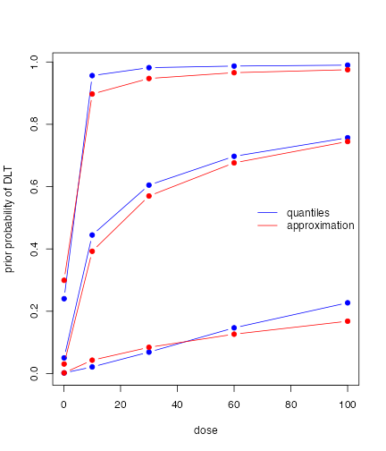

```r
matplot(
  x = coarseGrid,
  y = minInfModel$required,
  type = "b", pch = 19, col = "blue", lty = 1,
  xlab = "dose",
  ylab = "prior probability of DLT"
)
matlines(
  x = coarseGrid,
  y = minInfModel$quantiles,
  type = "b", pch = 19, col = "red", lty = 1
)
legend("right",
  legend = c("quantiles", "approximation"),
  col = c("blue", "red"),
  lty = 1,
  bty = "n"
)
```

In this plot we see in blue the quantiles (2.5%, 50%, and 97.5%) of the Beta distributions that we approximate with the red quantiles of the logistic normal model. We see that the distance is still quite large, and the maximum distance between any red and blue point is:

```r
minInfModel$distance
```

```
#> [1] 0.05912244
```

Therefore usually we would let the computations take longer (by removing the `control` option from the `MinimalInformative` call) to obtain a better approximation. The final approximating model, which has produced the red points, is contained in the `model` list element:

```r
str(minInfModel$model)
```

```
#> Formal class 'LogisticNormal' [package "crmPack"] with 9 slots
#>   ..@ params         :Formal class 'ModelParamsNormal' [package "crmPack"] with 3 slots
#>   .. .. ..@ mean: Named num [1:2] 0.6 0.654
#>   .. .. .. ..- attr(*, "names")= chr [1:2] "meanAlpha" "meanBeta"
#>   .. .. ..@ cov : num [1:2, 1:2] 1.81 1.83e-04 1.83e-04 1.07e-05
#>   .. .. ..@ prec: num [1:2, 1:2] 0.554 -9.441 -9.441 93435.615
#>   ..@ ref_dose       :Formal class 'positive_number' [package "crmPack"] with 1 slot
#>   .. .. ..@ .Data: num 50
#>   ..@ datamodel      :function ()
#>   .. ..- attr(*, "srcref")= 'srcref' int [1:8] 220 17 225 5 17 5 220 225
#>   .. .. ..- attr(*, "srcfile")=Classes 'srcfilecopy', 'srcfile' <environment: 0x753f7d1150>
#>   ..@ priormodel     :function ()
#>   .. ..- attr(*, "srcref")= 'srcref' int [1:8] 226 18 230 5 18 5 226 230
#>   .. .. ..- attr(*, "srcfile")=Classes 'srcfilecopy', 'srcfile' <environment: 0x753f7d1150>
#>   ..@ modelspecs     :function (from_prior)
#>   .. ..- attr(*, "srcref")= 'srcref' int [1:8] 151 18 157 5 18 5 151 157
#>   .. .. ..- attr(*, "srcfile")=Classes 'srcfilecopy', 'srcfile' <environment: 0x753f7d1150>
#>   ..@ init           :function ()
#>   .. ..- attr(*, "srcref")= 'srcref' int [1:8] 158 12 160 5 12 5 158 160
#>   .. .. ..- attr(*, "srcfile")=Classes 'srcfilecopy', 'srcfile' <environment: 0x753f7d1150>
#>   ..@ datanames      : chr [1:3] "nObs" "y" "x"
#>   ..@ datanames_prior: chr(0)
#>   ..@ sample         : chr [1:2] "alpha0" "alpha1"
```

Here we see in the slots `mean`, `cov` the parameters that have been determined. At this point a slight warning: you cannot directly change these parameters in the slots of the existing model object, because the parameters have also been saved invisibly in other places in the model object. Therefore, always use the class initialization function to create a new model object, if new parameters are required. But if we want to further use the approximation model, we can save it under a shorter name, e.g.:

```r
myModel <- minInfModel$model
```

# 6 Obtaining the posterior

As said before, models inheriting from the `GeneralModel` class rely on MCMC sampling for obtaining the posterior distribution of the model parameters, given the data. Most of the models, except the `EffFlexi` class model (please refer to Dual-endpoint dose escalation designs for details), inheriting from the `ModelPseudo` class do not necessarily require MCMC sampling to obtain posterior estimates. When no MCMC sampling is involved, the prior or posterior modal estimates of model estimates are used. But we can still obtain the full posterior distribution of the model parameters via MCMC for any models specified under `ModelPseudo` class. The MCMC sampling can be controlled with an object of class `mcmcOptions`, created for example as follows:

```r
options <- McmcOptions(
  burnin = 100,
  step = 2,
  samples = 2000,
  rng_kind = "Mersenne-Twister",
  rng_seed = 4991
)
```

Now the object `options` specifies that you would like to have `2000` parameter samples obtained from a Markov chain that starts with a `burn-in` phase of `100` iterations that are discarded, and then save a sample every `2` iterations. Note that these numbers are too low for actual production use and are only used for illustrating purposes here; normally you would specify at least the default parameters of the initialization function `mcmcOptions`: `10000` burn-in iterations and `10000` samples saved every 2<sup>nd</sup> iteration. In order to make the results reproducible, you also need to specify the `rng_kind` and `rng_seed`. Otherwise you will experience differences in the MCMC sampling, and therefore results. You can look these up in help browser under the link `McmcOptions`.

After having set up the options, you can proceed to MCMC sampling by calling the `mcmc` function:

```r
set.seed(94)
samples <- mcmc(data, model, options)
```

The `mcmc` function takes the data object, the model and the MCMC options. By default, JAGS is used for obtaining the samples. Use the option `verbose = TRUE` to show a progress bar and detailed JAGS messages.

Finally, it is good practice to check graphically that the Markov chain has really converged to the posterior distribution. To this end, `crmPack` provides an interface to the convenient `R`-package `ggmcmc`. With the function `get` you can extract the individual parameters from the object of class `Samples`.

For example, we extract the $\alpha_{0}$ samples: (please have a look at the help page for the `LogisticLogNormal` model class for the interpretation of the parameters)

```r
## look at the structure of the samples object:
str(samples)
```

```
#> Formal class 'Samples' [package "crmPack"] with 2 slots
#>   ..@ data   :List of 2
#>   .. ..$ alpha0: num [1:2000] 0.321 0.321 0.321 0.208 0.208 ...
#>   .. ..$ alpha1: num [1:2000] 1.97 1.97 1.97 0.778 0.778 ...
#>   ..@ options:Formal class 'McmcOptions' [package "crmPack"] with 5 slots
#>   .. .. ..@ iterations: int 4100
#>   .. .. ..@ burnin    : int 100
#>   .. .. ..@ step      : int 2
#>   .. .. ..@ rng_kind  : chr "base::Mersenne-Twister"
#>   .. .. ..@ rng_seed  : int 4991
## now extract the alpha0 samples (intercept of the regression model)
```

```r
alpha0samples <- get(samples, "alpha0")
```

`alpha0samples` now contains the $\alpha_{0}$ samples in a format understood by `ggmcmc` and we can produce plots with it, e.g. a trace plot and an autocorrelation plot:

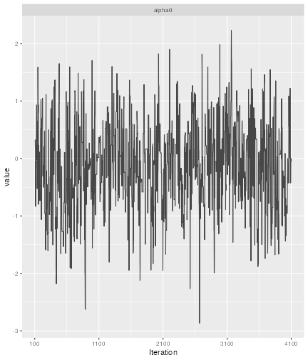

```r
library(ggmcmc)
print(ggs_traceplot(alpha0samples))
```

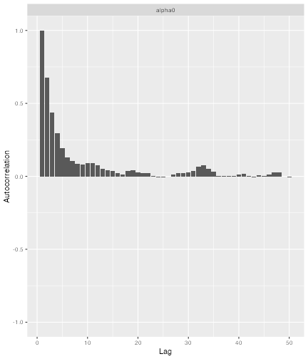

```r
print(ggs_autocorrelation(alpha0samples))
```

So here we see that we have some autocorrelation in the samples, and might consider using a higher thinning parameter in order to decrease it.

You can find other useful plotting functions in the package information:

```r
help(package = "ggmcmc", help_type = "html")
```

Similarly, using models from `ModelPseudo` class, we can also obtain the prior and posterior samples of the model parameters via MCMC.

For example, using the DLTmodel, `data1`, the empty data set and options specified in earlier examples.

```r
DLTsamples <- mcmc(data = data1, model = DLTmodel, options = options)
```

The prior samples of the model parameters are now saved in the variable `DLTsamples`.

```r
data3 <- Data(
  x = c(25, 50, 50, 75, 100, 100, 225, 300),
  y = c(0, 0, 0, 0, 1, 1, 1, 1),
  ID = as.integer(1:8),
  cohort = c(1, 2, 2, 3, 4, 4, 5, 6),
  doseGrid = seq(from = 25, to = 300, by = 25)
)
DLTpostsamples <- mcmc(data = data3, model = DLTmodel, options = options)
```

This `mcmc` function also takes the data object, model and the MCMC options. This is not using JAGS but just R for the computations.

Under this `DLTmodel`, we will obtain samples of φ<sub>1</sub> and φ<sub>2</sub>. Using what has been described earlier in this section , we can also look at the structure using function `str`, extracting model parameters samples with `get` and produce plots with `ggs_traceplot` and `ggs_autocorrelation` for each of the model parameters.

For example, we have some new observations specified in the data set `data3` and update the DLT model:

```r
newDLTmodel <- update(object = DLTmodel, data = data3)
newDLTmodel@phi1
```

```
#> [1] -5.070681
```

```r
newDLTmodel@phi2
```

```
#> [1] 1.125107
```

In the example, the `update` function is used to obtain the posterior modal estimates of the model parameters, φ<sub>1</sub> and φ<sub>2</sub>, which can then be extracted using the operator on the updated result `newDLTmodel`.

# 7 Plotting the model fit

After having obtained the parameter samples, we can plot the model fit, by supplying the samples, model and data to the generic plot function:

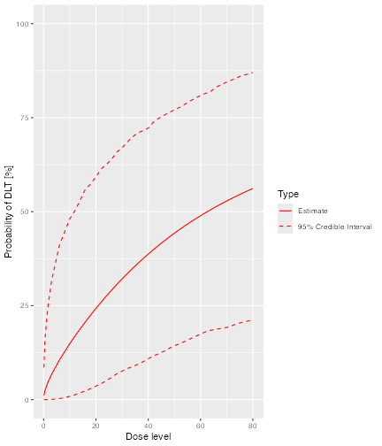

```r
print(plot(samples, model, data))
```

This plot shows the posterior mean curve and 95% equi-tailed credible intervals at each point of the dose grid from the `Data` object.

Note that you can also produce a plot of the prior mean curve and credible intervals, i.e. from the model without any data. This works in principle the same way as with data, just that we use an empty data object:

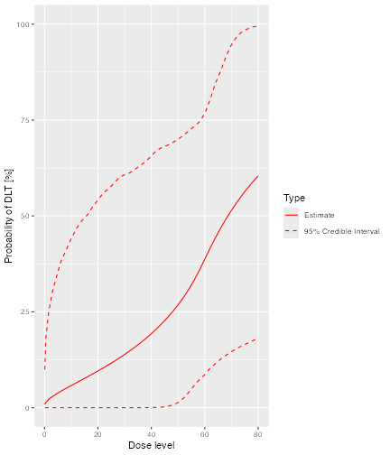

```r
## provide only the dose grid:
emptydata <- Data(doseGrid = data@doseGrid)
## obtain prior samples with this Data object
priorsamples <- mcmc(emptydata, model, options)
## then produce the plot
print(plot(priorsamples, model, emptydata))
```

This `plot` function can also apply to the `DLTmodel` when samples of the parameters have been generated:

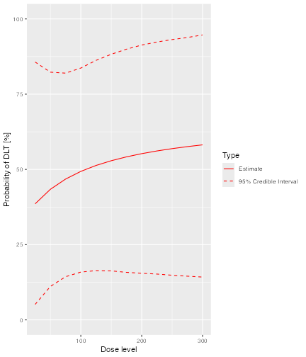

```r
print(plot(DLTsamples, DLTmodel, data1))
```

In addition, we can also plot the fitted dose-response curve using the prior or the posterior modal estimates of the model parameters when no MCMC sampling is used. For example, we have the `DLTmodel` specified earlier under the `ModelTox` class with the data set `data1` we specified earlier:

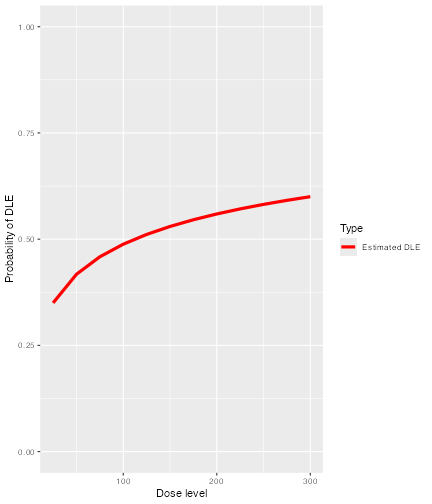

```r
print(plot(data1, DLTmodel))
```

Since no samples are involved, only the curve using the prior or posterior modal estimates of the parameters are produced, without 95% credibility intervals.

# 8 Escalation Rules

For the dose escalation, there are four kinds of rules:

- `Increments`: For specifying maximum allowable increments between doses
- `NextBest`: How to derive the next best dose
- `CohortSize`: For specifying the cohort size
- `Stopping`: Stopping rules for finishing the dose escalation

We have listed here the classes of these rules, and there are multiple subclasses for each of them, which you can find as links in the help pages `Increments-class`, `NextBest-class`, `CohortSize-class` and `Stopping-class`.

## 8.1 Increments rules

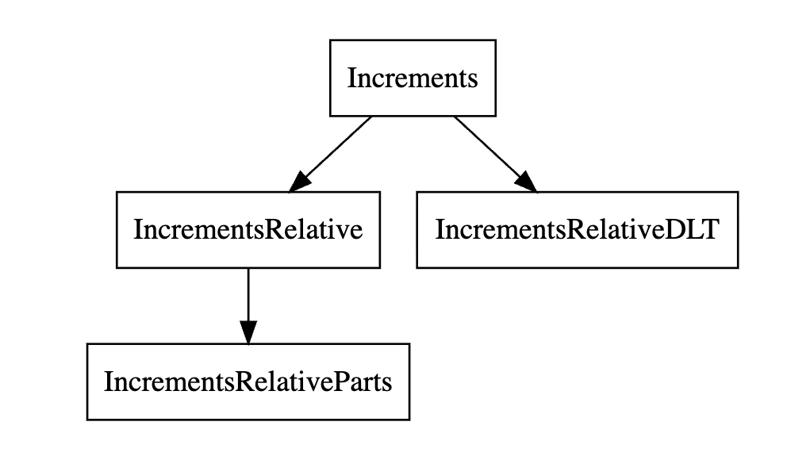

Increments classes structure

The `Increments` class is the basis for all maximum increments rule classes within this package. There are three subclasses, the `IncrementsRelative`, the `IncrementsRelativeParts` and the `IncrementsRelativeDLTs` classes. Let us start with looking in detail at the increments rules. Currently two specific rules are implemented: Maximum relative increments based on the current dose (`IncrementsRelative` and `IncrementsRelativeParts`, which only works with `DataParts` objects), and maximum relative increments based on the current cumulative number of DLTs that have happened (`IncrementsRelativeDLT`).

For example, in order to specify a maximum increase of 100% for doses up to 20 mg, and a maximum of 33% for doses above 20 mg, we can setup the following increments rule:

```r
myIncrements <- IncrementsRelative(
  intervals = c(0, 20),
  increments = c(1, 0.33)
)
```

Here the `intervals` slot specifies the left bounds of the intervals, in which the maximum relative `Increments` (note: decimal values here, no percentages!) are valid.

The increments rule is used by the `maxDose` function to obtain the maximum allowable dose given the current data:

```r
nextMaxDose <- maxDose(myIncrements,
  data = data
)
nextMaxDose
```

```
#> [1] 20
```

So in this case, the next dose could not be larger than 20 mg.

In the following example the dose escalation will be restricted to a 3-fold (= 200%) increase:

```r
myIncrements1 <- IncrementsRelative(
  intervals = c(25),
  increments = c(2)
)
```

From all doses (since the dose grid starts at 25 mg) there is a maximum increase of 200% here.

The `IncrementsRelativeDLT` class works similarly, taking the number of DLTs in the whole trial so far as the basis for the maximum increments instead of the last dose.

## 8.2 Rules for next best dose recommendation

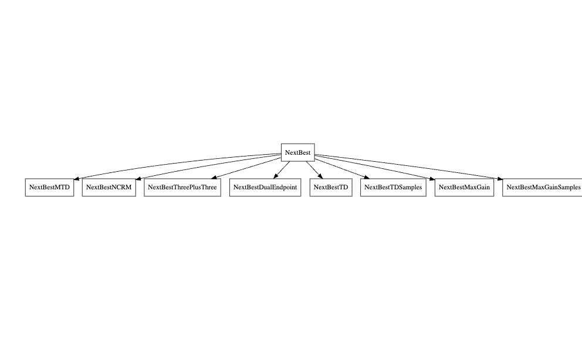

Escalation classes structure

All classes of escalation rules are contained in the `nextBest` class. There are two main types of escalation rules: either only the binary DLT responses are incorporated into the escalation process, or a binary DLT and a continuous efficacy/biomarker response are jointly incorporated into the escalation process.

There are two implemented rules for toxicity endpoint CRMs inheriting from the `GeneralModel` class: `NextBestMTD` that uses the posterior distribution of the MTD estimate (given a target toxicity probability defining the MTD), and `nextBestCRM` that implements the N-CRM, using posterior probabilities of target-dosing and overdosing at the dose grid points to recommend a next best dose.

For example, in order to use the N-CRM with a target toxicity interval from 20% to 35%, and a maximum overdosing probability of 25%, we specify:

```r
myNextBest <- NextBestNCRM(
  target = c(0.2, 0.35),
  overdose = c(0.35, 1),
  max_overdose_prob = 0.25
)
```

Alternatively, we could use an MTD driven recommendation rule. For example, with a target toxicity rate of 33%, and recommending the 25% posterior quantile of the MTD, we specify

```r
mtdNextBest <- NextBestMTD(
  target = 0.33,
  derive =
    function(mtd_samples) {
      quantile(mtd_samples, probs = 0.25)
    }
)
```

Note that the `NextBestMTD` class is quite flexible, because you can specify a function `derive` that derives the next best dose from the posterior MTD samples.

There are also two further next best dose recommendation rules when the model is inheriting from the `ModelTox` class. One rule is specified when no samples for the model parameters are involved and the other one is when samples of the model parameters are generated and are incorporated into the dose-escalation procedure.

The details about these rules are as follows. First, two probabilities of the occurrence of a DLT have to be fixed. The first one is called `targetDuringTrial` which is the target probability of the occurrence of a DLT to be used during the trial. The second probability is called `targetEndOfTrial` is the target probability of the occurrence of a DLT to be used at the end of a trial. The above two targets always have to be specified. For cases when samples are involved, an additional argument has to be used, which is a function to advise what we should recommend using the samples that we have. This will be elaborated in details in the example below.

```r
TDNextBest <- NextBestTD(
  prob_target_drt = 0.35,
  prob_target_eot = 0.3
)
```

In this example, we fixed the target probability of the occurrence of a DLT to be used during the trial be 0.35. This means we will allow subjects to dose levels with probability of DLT closest and less than or equal 0.35 during the trial. At the end of the trial, we will therefore recommend a dose level which is closest and with probability of DLT less than or equal to 0.3. This `NextBestTD` rule class can be only used when no samples are involved in the escalation procedure. Next we will show an example of the `NextBestTDsamples` rule class when samples are involved in the escalation process.

```r
TDsamplesNextBest <- NextBestTDsamples(
  prob_target_drt = 0.35,
  prob_target_eot = 0.3,
  derive = function(samples) {
    as.numeric(quantile(samples, probs = 0.3))
  }
)
```

The slot for `targetDuringTrial` and `targetEndOfTrial` are specified in the same way as in the last example given the value of 0.35 and 0.3, respectively. The `derive` slot should always be specified with a function. In this example, using the function specified in the `derive` slot says that we will recommend the 30% posterior quantiles of the samples to be the estimates for the doses corresponding to the `targetDuringTrial` and `targetEndOfTrial` doses.

During the study, in order to derive the next best dose, we supply the generic `nextBest` function with the rule, the maximum dose, the posterior samples, the model and the data:

```r
doseRecommendation <- nextBest(myNextBest,
  doselimit = nextMaxDose,
  samples = samples, model = model, data = data
)
```

```r
doseRecommendation$value
```

```
#> [1] 20
```

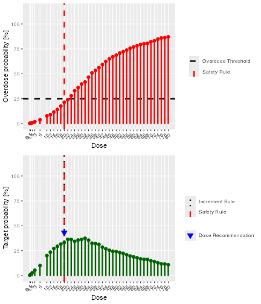

```r
print(doseRecommendation$plot)
```

Similarly, we can use the the generic `nextBest` function for the`NextBestTD` and `NextBestTDsamples` rules. In the example below we will use the data set `data3` with DLT observations. We can compute the next best dose to be given to the next cohort using the posterior modal estimates of the DLT model (i.e., no MCMC sampling involved here):

```r
doseRecDLT <- nextBest(TDNextBest, doselimit = 300, model = newDLTmodel, data = data3)
```

A list of numerical values and a plot showing how the next best dose was computed will be given. This list of results will provide the numerical values for the next dose level, `next_dose_drt`; the target probability of DLT used during the trial, `prob_target_drt`; the estimated dose level for which its probability of DLT equals the target probability used during the trial, `dose_target_drt`; the target probability of DLT used at the end of a trial, `prob_target_eot`; the estimated dose level for which its probability of DLT equals the target probability of DLT used at the end of a trial `dose_target_eot`; and the dose level at dose grid closest and less than the `dose_target_eot`, `next_dose_eot`. We can use the `$` operator to obtain these values and the plot from the list. For example,

```r
doseRecDLT$next_dose_drt
```

```
#> [1] 50
```

```r
doseRecDLT$prob_target_drt
```

```
#> [1] 0.35
```

```r
doseRecDLT$dose_target_drt
```

```
#> [1] 52.28128
```

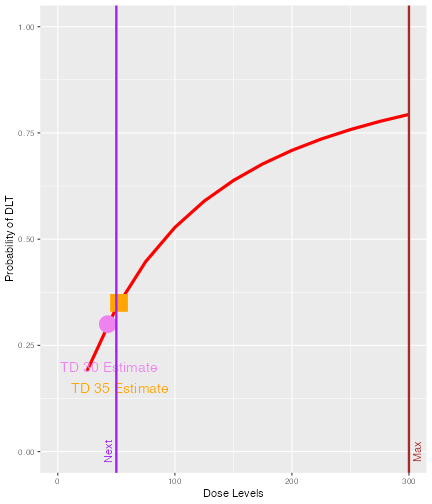

```r
print(doseRecDLT$plot)
```

We can see that the next dose suggested to be given to the next cohort of subjects is 50 mg. The target probability of DLT during the trial is 0.35 and the TD35 (the tolerated dose with probability of DLT equal to 0.35) is estimated to be 52.28 mg. As we are using 12 dose levels or dose grids from 25 mg to 300 mg with increments of 25 mg for this data set, `data3`, we can see that what is suggested for the next dose 50 mg is also the dose level closest below 52.28 mg, the estimated `dose_target_drt`. Similarly, at the end of a trial we could also obtain all “End Of Trial” estimates by using the `$` operator. In addition, we also have a plot to show next dose allocation. The red curve shows the estimated DLT curve obtained using the posterior modal estimates of the model parameters. We also assumed the maximum allowable dose be 300 mg which was specified as the `doselimit` parameter of the `nextBest` function call and the red vertical line denoted with “Max” shows the maximum dose level (at x-axis) that is allowed in this case. The vertical purple line denoted with “Next” marks the dose level to be allocated to the next cohort of subjects. In this example, the target probability of DLT used during trial and at the end of a trial were 0.35 and 0.3, respectively. The circle and the square on the DLT curve show where the probability of DLT is estimated to be equal to 0.3 and 0.35, respectively. Hence, the value of the estimated TD30 and TD35 can be checked at the x-axis vertically below these symbols.

When MCMC sampling is involved, we will use the samples of model parameters to choose the next best dose. For example, in the following code chunk we use the data set, `data3`, with some DLT observations and the posterior samples of the model parameters, `DLTpostsamples` to compute the next best dose:

```r
doseRecDLTSamples <- nextBest(TDsamplesNextBest,
  doselimit = 300,
  samples = DLTpostsamples, model = newDLTmodel,
  data = data3
)
```

The same list of results will be produced as in the example before: The values of the `next_dose_drt`, `prob_target_drt`, `dose_target_drt`, `prob_target_eot`, `dose_target_eot` and `next_dose_eot` can be obtained using the `$` operator. The only difference is that the plot in this example will look slightly different than in the previous example:

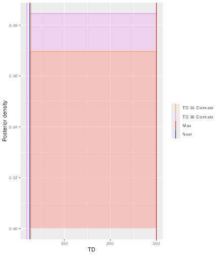

```r
print(doseRecDLTSamples$plot)
```

> This graph is incorrect

## 8.3 Cohort size rules

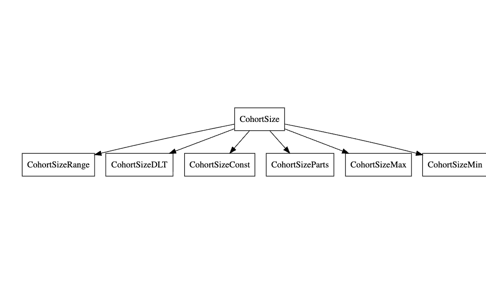

CohortSize classes structure

```r
df <- data.frame(
  pathString = c(
    "CohortSize/CohortSizeRange",
    "CohortSize/CohortSizeDLT",
    "CohortSize/CohortSizeConst",
    "CohortSize/CohortSizeParts",
    "CohortSize/CohortSizeMax",
    "CohortSize/CohortSizeMin"
  )
)

tree <- as.Node(df)
SetNodeStyle(tree, shape = "box", fig.alt = "A dendrogram showing the inheritance stricture of the CohortSize classes.  CohortSie is the parent class.  All other classes are children of CohortSize.")
plot(tree)
```

Similarly to the increments rules, you can define intervals in the dose space and/or the DLT space to define the size of the cohorts. For example, let’s assume we want to have one patient only in the cohorts until we reach 30 mg or the first DLT is encountered, and then proceed with three patients per cohort.

We start by creating the two separate rules, first for the dose range:

```r
mySize1 <- CohortSizeRange(intervals = c(0, 30), cohort_size = c(1, 3))
```

Then for the DLT range:

```r
mySize2 <- CohortSizeDLT(intervals = c(0, 1), cohort_size = c(1, 3))
```

Finally we combine the two rules by taking the maximum number of patients of both rules:

```r
mySize <- maxSize(mySize1, mySize2)
```

```r
size(mySize,
  dose = doseRecommendation$value,
  data = data
)
```

```
#> [1] 3
```

Here, because we have one DLT already, we would go for 3 patients for the next cohort.

Moreover, if you would like to have a constant cohort size, you can use the following `CohortSizeConst` class, which we will use (with three patients) for simplicity for the remainder of this vignette:

```r
mySize <- CohortSizeConst(size = 3)
```

## 8.4 Stopping rules

All of the stopping rules classes inherit directly from the `Stopping` class. There are in total 9 stopping rules, listed as follows:

- `StoppingCohortNearDose`
- `StoppingPatientsNearDose`
- `StoppingMinCohorts`
- `StoppingMinPatients`
- `StoppingTargetProb`
- `StoppingMTDdistribution`
- `StoppingTargetBiomarker`
- `StoppingTDCIRatio`
- `StoppingMaxGainCIRatio`

From the names of these stopping rules, we can have an idea of what criteria have been used for stopping decisions and we will explain briefly here what are these criteria. For further details please refer to examples presented later in this vignette or examples given in the help pages. You can find a link to all implemented stopping rule parts in the help page `Stopping-class`.

For example, `StoppingCohortNearDose` class objects can be used to stop the dose escalation based on the numbers of cohorts treated near to the next best dose (where the required proximity is given as the percentage of relative deviation from the next best dose). Similarly, for `StoppingPatientsNearDose`, stopping is based on the number of patients treated near the next best dose. `StoppingMinCohorts` and `StoppingMinPatients` rules can be used to stop the dose escalation if a minimum overall number of patients or cohorts have been enrolled. We have also other stopping rules such that a trial will be stopped either based on the MTD distribution (`StoppingMTDdistribution`), or reached a pre-specified probability of the next dose being in the target toxicity interval (`StoppingTargetProb`) or target biomarker interval (`StoppingTargetBiomarker`) or when the current estimate of the quantity of interest is ‘accurate’ enough (`StoppingTDCIRatio` and `StoppingMaxGainCIRatio`)

Stopping rules are often quite complex, because they are built from “and/or” combinations of multiple parts. Therefore the `crmPack` implementation mirrors this, and multiple atomic stopping rules can be combined easily. For example, let’s assume we would like to stop the trial if there are at least 3 cohorts and at least 50% probability in the target toxicity interval $(20%, 35%)$, or the maximum sample size of 20 patients has been reached.

Then we start by creating the three pieces the rule is composed of:

```r
myStopping1 <- StoppingMinCohorts(nCohorts = 3)
myStopping2 <- StoppingTargetProb(
  target = c(0.2, 0.35),
  prob = 0.5
)
myStopping3 <- StoppingMinPatients(nPatients = 20)
```

Finally we combine these with the `and` operator `&` and the `or` operator `|`:

```r
myStopping <- (myStopping1 & myStopping2) | myStopping3
```

We can also stop the trial when the current estimate of the quantity of interest, such as the TD30 given in earlier examples, is ‘accurate’ enough. The accuracy of the current estimate of TD30 is quantified by the width of the associated 95% credibility interval. The wider the interval, the less accurate the estimate is. In particular, the ratio of the upper to the lower limit of this 95% credibility interval is used. The smaller the ratio, the more accurate is the estimate.

For example, we will stop our trial if we obtain a ratio of less than 5 for the 95% credibility interval of the TD30 estimate in this case, deciding that we have obtained an estimate which is ‘accurate’ enough.

The `StoppingTDCIRatio` function can be used in both cases when no DLT samples or DLT samples are involved:

```r
myStopping4 <- StoppingTDCIRatio(target_ratio = 5, prob_target = 0.3)
```

> In the above two examples, the `targetRatio` and `targetEndOfTrial` has to be specified.

During the dose escalation study, any (atomic or combined) stopping rule can be used by the function `stopTrial` to determine if the rule has already been fulfilled. For example in our case:

```r
stopTrial(
  stopping = myStopping, dose = doseRecommendation$value,
  samples = samples, model = model, data = data
)
```

```
#> [1] FALSE
#> attr(,"message")
#> attr(,"message")[[1]]
#> attr(,"message")[[1]][[1]]
#> [1] "Number of cohorts is 6 and thus reached the prespecified minimum number 3"
#>
#> attr(,"message")[[1]][[2]]
#> [1] "Probability for target toxicity is 33 % for dose 20 and thus below the required 50 %"
#>
#>
#> attr(,"message")[[2]]
#> [1] "Number of patients is 8 and thus below the prespecified minimum number 20"
#>
#> attr(,"individual")
#> attr(,"individual")[[1]]
#> [1] FALSE
#> attr(,"message")
#> attr(,"message")[[1]]
#> [1] "Number of cohorts is 6 and thus reached the prespecified minimum number 3"
#>
#> attr(,"message")[[2]]
#> [1] "Probability for target toxicity is 33 % for dose 20 and thus below the required 50 %"
#>
#> attr(,"individual")
#> attr(,"individual")[[1]]
#> [1] TRUE
#> attr(,"message")
#> [1] "Number of cohorts is 6 and thus reached the prespecified minimum number 3"
#> attr(,"report_label")
#> [1] "≥ 3 cohorts dosed"
#>
#> attr(,"individual")[[2]]
#> [1] FALSE
#> attr(,"message")
#> [1] "Probability for target toxicity is 33 % for dose 20 and thus below the required 50 %"
#> attr(,"report_label")
#> [1] "P(0.2 ≤ prob(DLE | NBD) ≤ 0.35) ≥ 0.5"
#>
#> attr(,"report_label")
#> [1] NA
#>
#> attr(,"individual")[[2]]
#> [1] FALSE
#> attr(,"message")
#> [1] "Number of patients is 8 and thus below the prespecified minimum number 20"
#> attr(,"report_label")
#> [1] "≥ 20 patients dosed"
#>
#> attr(,"report_label")
#> [1] NA
```

In the same way the stopping rule `myStopping4` (no samples and with samples) can be evaluated:

```r
stopTrial(
  stopping = myStopping4, dose = doseRecDLTSamples$next_dose_drt,
  samples = DLTpostsamples, model = newDLTmodel, data = data3
)
```

```
#> [1] FALSE
#> attr(,"message")
#> [1] "95% CI is (0.000611274483578011, 10459.1345133637), Ratio = 17110373.1537 is greater than target_ratio = 5"
#> attr(,"report_label")
#> [1] "TD 5 for 0.3 target prob"
```

```r
stopTrial(
  stopping = myStopping4, dose = doseRecDLT$next_dose_drt,
  model = newDLTmodel, data = data3
)
```

```
#> [1] FALSE
#> attr(,"message")
#> [1] "95% CI is ( 11.0662 , 164.618 ), Ratio = 14.8758 is  greater than target_ratio = 5"
#> attr(,"report_label")
#> [1] "TD 5 for 0.3 target prob"
```

when DLT samples or no DLT samples are involved.

> Note that at the moment the `and` operator `&` and the `or` operator `|` cannot be used together with `StoppingTDCIRatio` class objects. This is still under development.

# 9 Simulations

In order to run simulations, we first have to build a specific design, that comprises a model, the escalation rules, starting data, a cohort size and a starting dose.

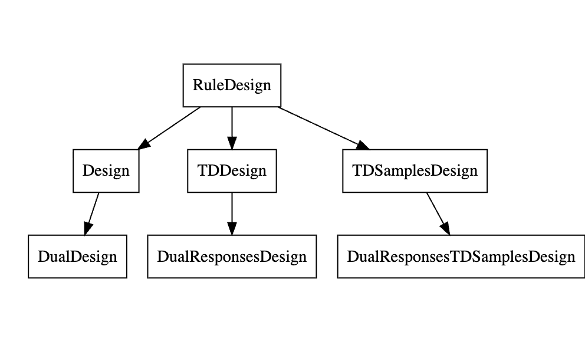

Design classes structure

```r
design <- Design(
  model = model,
  nextBest = myNextBest,
  stopping = myStopping,
  increments = myIncrements,
  cohort_size = mySize,
  data = emptydata,
  startingDose = 3
)
```

Another example will be given when the `TDDesign` class is used. The empty data set, `data1` will be used, and the starting dose will be 25 mg. The code below will be a design defined when no MCMC sampling is involved. The `nextBest` slot under this `TDDesign` class function has to be defined with the `TDNextBest` class object to ensure we will pick the next best dose using rules as defined when no MCMC sampling is involved. In addition, we define here with `myStopping4` that the trial will only stop when the ratio of the 95% credibility interval limits of the current estimate of TD30 (`TDtargetEndOfTrial`) is less than or equal to 5. In addition, we also use `myIncrements1`, `mySize` and `data1` defined in earlier examples for the `increments`, `cohort_size` and `data` slots in defining the `TDDesign` object:

```r
DLTdesign <- TDDesign(
  model = DLTmodel,
  nextBest = TDNextBest,
  stopping = myStopping4,
  increments = myIncrements1,
  cohort_size = mySize,
  data = data1,
  startingDose = 25
)
```

```r
DLTsamplesDesign <- TDsamplesDesign(
  model = DLTmodel,
  nextBest = TDsamplesNextBest,
  stopping = (myStopping4 | myStopping3),
  increments = myIncrements1,
  cohort_size = mySize,
  data = data1,
  startingDose = 25
)
```

## 9.1 Examining single trial behavior

Before looking at the “many trials” operating characteristics, it is important to look at the “single trial” operating characteristics of the dose escalation design. For this, `crmPack` provides the function `examine`, which generates a `data.frame` showing the beginning of several hypothetical trial courses under the design. Assuming no DLTs have been seen until a certain dose, then the consequences of different number of DLTs being observed at this dose are shown. In the current example we have

```r
set.seed(23)
examine(design)
```

```
#>    dose DLTs nextDose  stop increment
#> 1     3    0      6.0 FALSE       100
#> 2     3    1      6.0 FALSE       100
#> 3     3    2      0.1 FALSE       -97
#> 4     3    3       NA FALSE        NA
#> 5     6    0     12.0 FALSE       100
#> 6     6    1     12.0 FALSE       100
#> 7     6    2      3.0 FALSE       -50
#> 8     6    3      1.5 FALSE       -75
#> 9    12    0     24.0 FALSE       100
#> 10   12    1     24.0 FALSE       100
#> 11   12    2     14.0 FALSE        17
#> 12   12    3      6.0 FALSE       -50
#> 13   24    0     30.0 FALSE        25
#> 14   24    1     30.0 FALSE        25
#> 15   24    2     26.0 FALSE         8
#> 16   24    3     18.0 FALSE       -25
#> 17   30    0     38.0 FALSE        27
#> 18   30    1     38.0 FALSE        27
#> 19   30    2     34.0 FALSE        13
#> 20   30    3     26.0 FALSE       -13
#> 21   38    0     50.0 FALSE        32
#> 22   38    1     50.0 FALSE        32
#> 23   38    2     42.0 FALSE        11
#> 24   38    3     36.0 FALSE        -5
#> 25   50    0     58.0  TRUE        16
#> 26   50    1     54.0  TRUE         8
#> 27   50    2     50.0  TRUE         0
#> 28   50    3     46.0  TRUE        -8
```

Note that it is important to set a seed, since minor changes might occur due to sampling variations. However, the `mcmcOptions` parameter should be chosen in order to minimize such variation. The default setting, used implicitly in the above call, should normally be sufficient, but checking this (by running the function twice with different seeds and comparing the results) is important.

The resulting data frame gives the dose of the cohort until which no DLTs are observed, the number of DLTs, the resulting next dose recommendation, whether the design would stop, and the relative increment of the next dose compared to the current dose in percentage. Note that cohort size rules are taken into account by `examine`. `NA` entries mean that the design would stop without a valid dose, since all doses are considered too toxic after observing the number of DLTs at that dose.

## 9.2 Simulating from a true scenario

For the “many trials” operating characteristics, we have to define a true scenario, from which the data should arise. In this case, this only requires a function that computes the probability of DLT given a dose. Here we use a specific case of the function contained in the model space:

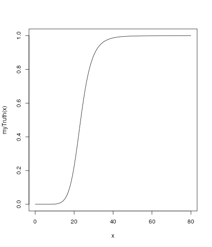

```r
## define the true function
myTruth <- probFunction(model, alpha0 = 7, alpha1 = 8)

## plot it in the range of the dose grid
curve(myTruth(x), from = 0, to = 80, ylim = c(0, 1))
```

In a similar way, we can also simulate trials based on a true DLT scenario using the `TDDesign` and the `TDsamplesDesign`.

First, we will specified the true DLT scenario such that

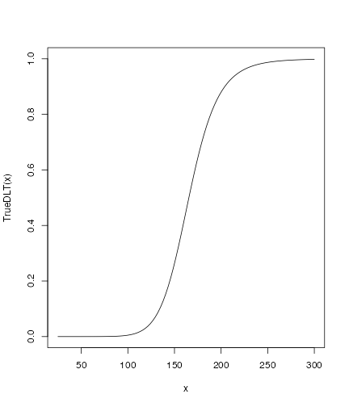

```r
## define the true function
TrueDLT <- probFunction(DLTmodel, phi1 = -53.66584, phi2 = 10.50499)

## plot it in the range of the dose grid
curve(TrueDLT, from = 25, to = 300, ylim = c(0, 1))
```

This true DLT scenario will be used for both the `TDDesign` and the `TDsamplesDesign`

Now we can proceed to the simulations. We only generate 100 trial outcomes here for illustration, for the actual study this should be increased of course to at least 500:

```r
time <- system.time(mySims <- simulate(design,
  args = NULL,
  truth = myTruth,
  nsim = 100,
  seed = 819,
  mcmcOptions = options,
  parallel = FALSE
))[3]
time
```

```
#> elapsed
#> 181.696
```

We have wrapped the call to `simulate` in a `system.time` to obtain the required time for the simulations (about 182 seconds in this case). The argument `args` could contain additional arguments for the `truth` function, which we did not require here and therefore let it at the default `NULL`. We specify the number of simulations with `nsim` and the random number generator seed with `seed`. Note that we also pass again the MCMC options object, because during the trial simulations the MCMC routines are used. Finally, the argument `parallel` can be used to enable the use of all processors of the computer for running the simulations in parallel. This can yield a meaningful speedup, especially for larger number of simulations.

As (almost) always, the result of this call is again an object with a class, in this case `Simulations`:

```r
class(mySims)
```

```
#> [1] "Simulations"
#> attr(,"package")
#> [1] "crmPack"
```

From the help page

```r
help("Simulations-class", help = "html")
```

we see that this class is a subclass of the `GeneralSimulations` class. By looking at the help pages for `Simulations` and the parent class `GeneralSimulations`, we can find the description of all slots of `mySims`. In particular, the `Data` slot contains the list of produced `Data` objects of the simulated trials. Therefore, we can plot the course of e.g. the third simulated trial as follows:

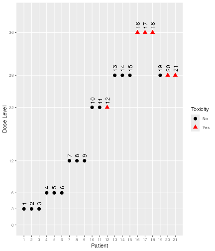

```r
print(plot(mySims@data[[3]]))
```

The final dose for this trial was

```r
mySims@doses[3]
```

```
#> [1] 22
```

and the stopping reason was

```r
mySims@stop_reasons[[3]]
```

```
#> [[1]]
#> [[1]][[1]]
#> [1] "Number of cohorts is 7 and thus reached the prespecified minimum number 3"
#>
#> [[1]][[2]]
#> [1] "Probability for target toxicity is 52 % for dose 22 and thus above the required 50 %"
#>
#>
#> [[2]]
#> [1] "Number of patients is 21 and thus reached the prespecified minimum number 20"
```

Furthermore, with this object, we can apply two methods. First, we can plot it, i.e. we can apply the plot method:

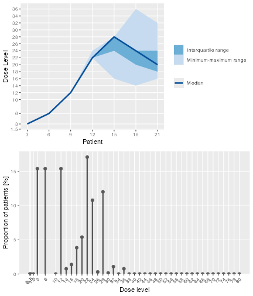

```r
print(plot(mySims))
```

The resulting plot shows on the top panel a summary of the trial trajectories. On the bottom, the proportions of doses tried, averaged over the simulated trials, are shown. Note that you can select the plots by changing the `type` argument of `plot`, which by default is `type = c("trajectory", "dosesTried")`.

Second, we can summarize the simulation results. Here again we have to supply a true dose-toxicity function. We take the same (`myTruth`) as above:

```r
summary(mySims,
  truth = myTruth
)
```

```
#> Summary of 100 simulations
#>
#> Target toxicity interval was 20, 35 %
#> Target dose interval corresponding to this was 19.6, 21.6
#> Intervals are corresponding to 10 and 90 % quantiles
#>
#> Number of patients overall : mean 19 (18, 21)
#> Number of patients treated above target tox interval : mean 8 (6, 12)
#> Proportions of DLTs in the trials : mean 26 % (22 %, 33 %)
#> Mean toxicity risks for the patients on active : mean 26 % (17 %, 35 %)
#> Doses selected as MTD : mean 20.6 (16, 24)
#> True toxicity at doses selected : mean 31 % (5 %, 56 %)
#> Proportion of trials selecting target MTD: 24 %
#> Dose most often selected as MTD: 20
#> Observed toxicity rate at dose most often selected: 21 %
#> Fitted toxicity rate at dose most often selected : mean 26 % (23 %, 33 %)
#> Overdose probability at selected dose : mean 20 % (15 %, 24 %)
#> Stop reason triggered:
#>  ≥ 3 cohorts dosed :  100 %
#>  P(0.2 ≤ prob(DLE | NBD) ≤ 0.35) ≥ 0.5 :  100 %
#>  ≥ 20 patients dosed :  48 %
```

Note that sometimes the observed toxicity rate at the dose most often selected (here 20 mg) is not available, because it can happen that no patients were actually treated that dose during the simulations. (Here it is available.) This illustrates that the MTD can be selected based on the evidence from the data at other dose levels – which is an advantage of model-based dose-escalation designs.

Now we can also produce a plot of the summary results, which gives a bit more detail than the textual summary we have just seen:

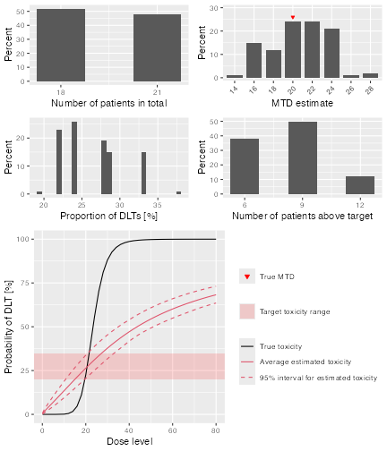

```r
simSum <- summary(mySims,
  truth = myTruth
)
print(plot(simSum))
```

The top left panel shows the distribution of the sample size across the simulated trials. In this case the trials had between 18 and 21 patients. The top right panel shows the distribution of the final MTD estimate / recommended dose across the simulated trials. The middle left panel shows the distribution across the simulations of the DLT proportions observed in the patients dosed. Here in most trials between 22 and 33% of the patients had DLTs. The middle right panel shows the distribution across simulations of the number of patients treated above the target toxicity window (here we used the default from 20% to 35%). Finally, in the bottom panel we see a comparison of the true dose-toxicity curve (black) with the estimated dose-toxicity curves, averaged (continuous red line) across the trials and with 95% credible interval across the trials. Here we see that the steep true dose-toxicity curve is not recovered by the model fit.

If we find that e.g. the top right plot with the distribution of the final selected doses is too small and shows not the right x-axis window, we can only plot this one and add x-axis customization on top: (see the `ggplot2` documentation for more information on customizing the plots)

```r
dosePlot <- plot(simSum, type = "doseSelected") +
  scale_x_continuous(breaks = 10:30, limits = c(10, 30))
print(dosePlot)
```

[output not shown]

Some further examples will be given for simulations using the `TDDesign` and the `TDsamplesDesign` classes. For illustration purpose, we will generate only 10 trial outcomes.

```r
DLTSim <- simulate(DLTdesign,
  args = NULL,
  truth = TrueDLT,
  nsim = 10,
  seed = 819,
  parallel = FALSE
)
```

The above is an example when no MCMC sampling is involved and we have another example below for simulation when MCMC sampling is involved:

```r
DLTsampSim <- simulate(DLTsamplesDesign,
  args = NULL,
  truth = TrueDLT,
  nsim = 10,
  seed = 819,
  mcmcOptions = options,
  parallel = FALSE
)
```

The meaning of these arguments are the same as those defined and explained above in the `simulate` example for the `Design` class. % With slots `args` to specify any additional arguments for the `truth` function, `truth` for the real DLT scenario to simulate responses from, `nsim` for the number of simulations, `seed`, the random generator seed and `parallel` to specify whether parallel computing is to be used for running the simulations.

Similarly, the results of individual simulations can be obtained graphically using the `plot` function. The dose level for recommendation that is the dose levels closest below the final estimated TD30 (the final estimates of the dose level with probability of DLT equals to the target end of trial) was

```r
DLTSim@doses[3]
```

```
#> [1] 100
```

```r
DLTsampSim@doses[3]
```

```
#> [1] 100
```

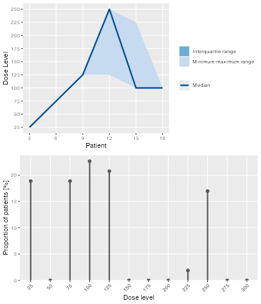

```r
print(plot(DLTSim))
```

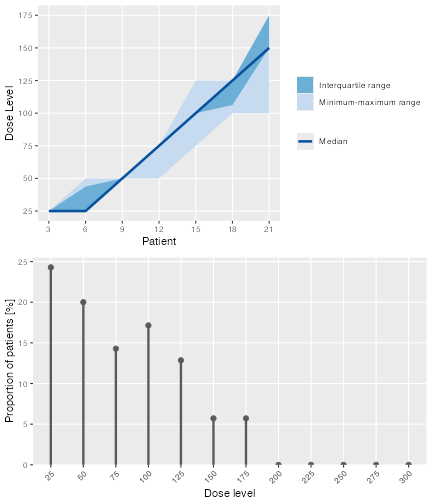

```r
print(plot(DLTsampSim))
```

which show the trial trajectories and the proportion of doses level tried.

These simulation results can also be summarized using the `summary` function given the truth:

```r
summary(DLTSim,
  truth = TrueDLT
)
```

```
#> Summary of 10 simulations
#>
#> Target probability of DLE p(DLE) used at the end of a trial was 30 %
#> The dose level corresponds to the target p(DLE) used at the end of a trial, TDEOT, was 152.6195
#> TDEOT at dose Grid was 150
#> Target p(DLE) used during a trial was 35 %
#> The dose level corresponds to the target p(DLE) used during a trial, TDDT, was 155.972
#> TDDT at dose Grid was 150
#> Number of patients overall : mean 16 (15, 18)
#> Number of patients treated above the target p(DLE) used at the end of a trial : mean 3 (3, 3)
#> Number of patients treated above the target p(DLE) used during a trial : mean 3 (3, 3)
#> Proportions of observed DLT in the trials : mean 21 % (20 %, 22 %)
#> Mean toxicity risks for the patients : mean 20 % (17 %, 21 %)
#> Doses selected as TDEOT : mean 100 (100, 100)
#> True toxicity at TDEOT : mean 1 % (1 %, 1 %)
#> Proportion of trials selecting the TDEOT: 0 %
#> Proportion of trials selecting the TDDT: 0 %
#> Dose most often selected as TDEOT: 100
#> Observed toxicity rate at dose most often selected: 6 %
#> Fitted probabilities of DLE at dose most often selected : mean 24 % (24 %, 25 %)
#> The summary table of the final TDEOT across all simulations
#>     Min. 1st Qu.  Median    Mean 3rd Qu.    Max.
#>    117.3   120.1   123.8   122.0   123.8   123.8
#> The summary table of the final ratios of the TDEOT across all simulations
#>     Min. 1st Qu.  Median    Mean 3rd Qu.    Max.
#>    4.054   4.157   4.447   4.330   4.447   4.447
#> The summary table of the final TDDT across all simulations
#>     Min. 1st Qu.  Median    Mean 3rd Qu.    Max.
#>    137.5   140.7   144.4   142.5   144.4   144.4
#> The summary table of dose levels, the optimal dose
#>  to recommend for subsequent study across all simulations
#>     Min. 1st Qu.  Median    Mean 3rd Qu.    Max.
#>    117.3   120.1   123.8   122.0   123.8   123.8
#> The summary table of the final ratios of the optimal dose for stopping across
#>                   all simulations
#>     Min. 1st Qu.  Median    Mean 3rd Qu.    Max.
#>    4.054   4.157   4.447   4.330   4.447   4.447
#>
#> Stop reason triggered:
#>  TD 5 for 0.3 target prob :  100 %
```

```r
summary(DLTsampSim,
  truth = TrueDLT
)
```

```
#> Summary of 10 simulations
#>
#> Target probability of DLE p(DLE) used at the end of a trial was 30 %
#> The dose level corresponds to the target p(DLE) used at the end of a trial, TDEOT, was 152.6195
#> TDEOT at dose Grid was 150
#> Target p(DLE) used during a trial was 35 %
#> The dose level corresponds to the target p(DLE) used during a trial, TDDT, was 155.972
#> TDDT at dose Grid was 150
#> Number of patients overall : mean 21 (21, 21)
#> Number of patients treated above the target p(DLE) used at the end of a trial : mean 1 (0, 3)
#> Number of patients treated above the target p(DLE) used during a trial : mean 1 (0, 3)
#> Proportions of observed DLT in the trials : mean 10 % (5 %, 14 %)
#> Mean toxicity risks for the patients : mean 6 % (1 %, 10 %)
#> Doses selected as TDEOT : mean 100 (75, 125)
#> True toxicity at TDEOT : mean 2 % (0 %, 5 %)
#> Proportion of trials selecting the TDEOT: 0 %
#> Proportion of trials selecting the TDDT: 0 %
#> Dose most often selected as TDEOT: 100
#> Observed toxicity rate at dose most often selected: 6 %
#> Fitted probabilities of DLE at dose most often selected : mean 22 % (18 %, 26 %)
#> The summary table of the final TDEOT across all simulations
#>     Min. 1st Qu.  Median    Mean 3rd Qu.    Max.
#>    97.28  100.35  115.37  114.40  125.23  135.76
#> The summary table of the final ratios of the TDEOT across all simulations
#>       Min.   1st Qu.    Median      Mean   3rd Qu.      Max.
#>  1.000e+01 6.800e+01 4.079e+06 5.241e+11 1.917e+11 3.806e+12
#> The summary table of the final TDDT across all simulations
#>     Min. 1st Qu.  Median    Mean 3rd Qu.    Max.
#>    118.8   122.2   144.9   143.3   161.5   170.3
#> The summary table of dose levels, the optimal dose
#>  to recommend for subsequent study across all simulations
#>     Min. 1st Qu.  Median    Mean 3rd Qu.    Max.
#>    97.28  100.35  115.37  114.40  125.23  135.76
#> The summary table of the final ratios of the optimal dose for stopping across
#>                   all simulations
#>       Min.   1st Qu.    Median      Mean   3rd Qu.      Max.
#>  1.000e+01 6.800e+01 4.079e+06 5.241e+11 1.917e+11 3.806e+12
#>
#> Stop reason triggered:
#>  TD 5 for 0.3 target prob :  0 %
#>  ≥ 20 patients dosed :  100 %
```

Then we can also plot the summary of these two simulations using the `plot` function:

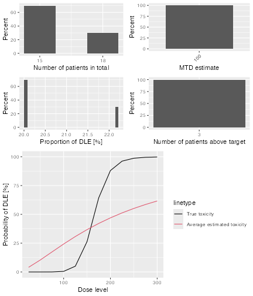

```r
DLTsimSum <- summary(DLTSim,
  truth = TrueDLT
)
print(plot(DLTsimSum))
```

and

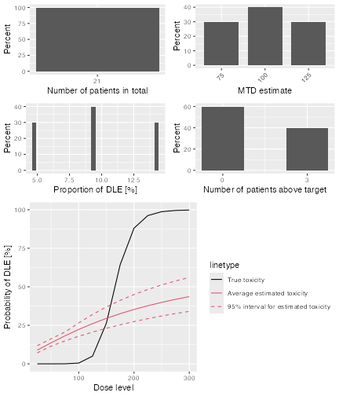

```r
DLTsimsampSum <- summary(DLTsampSim,
  truth = TrueDLT
)
print(plot(DLTsimsampSum))
```

## 9.3 Predicting the future course of the trial

By simulating parameters from their current posterior distribution instead of an assumed true scenario, it is possible to generate trial simulations from the posterior predictive distribution at any time point during the trial. This means that we can predict the future course of the trial, given the current data. In our illustrating example, this would work as follows.

The rationale of the `simulate` call is now that we specify as the `truth` argument the `prob` function from our assumed model.

```r
postSamples <- as.data.frame(samples@data)[(1:20) * 50, ]
postSamples
```

```
#>          alpha0    alpha1
#> 50   -1.0642746 0.9880961
#> 100  -1.3205596 1.2035031
#> 150  -0.2787745 1.1420241
#> 200  -0.6736342 1.9538039
#> 250  -0.3450108 1.6705798
#> 300  -0.5117568 1.0511386
#> 350   0.2383558 1.0875325
#> 400   0.7832575 1.4880692
#> 450   0.1441964 0.4854883
#> 500   0.3672222 1.1369901
#> 550   0.5250996 0.7058702
#> 600   0.2357070 1.2774505
#> 650  -0.7399773 0.4011145
#> 700  -0.2415685 0.4412713
#> 750  -0.1679610 1.1685310
#> 800   0.4211765 0.5613394
#> 850   0.4369553 1.3116985
#> 900   0.5305816 1.4328609
#> 950  -0.5691799 0.4664936
#> 1000 -1.2305607 1.4746557
```

Therefore, each simulated trial will come from a posterior sample of our estimated model, given all data so far.

Furthermore we have to make a new `Design` object that contains the current data to start from, and the current recommended dose as the starting dose:

```r
nowDesign <- Design(
  model = model,
  nextBest = myNextBest,
  stopping = myStopping,
  increments = myIncrements,
  cohort_size = mySize,
  ## use the current data:
  data = data,
  ## and the recommended dose as the starting dose:
  startingDose = doseRecommendation$value
)
```

Finally we can execute the simulations:

```r
time <- system.time(futureSims <- simulate(
  ## supply the new design here
  nowDesign,
  ## the truth is the assumed prob function
  truth = function(dose, alpha0, alpha1) {
    samples <- Samples(
      data = list(alpha0 = alpha0, alpha1 = alpha1),
      options = McmcOptions(samples = 1)
    )
    prob(dose, model, samples)
  },
  ## further arguments are the
  ## posterior samples
  args = postSamples,
  ## do exactly so many simulations as
  ## we have samples
  nsim = nrow(postSamples),
  seed = 918,
  ## this remains the same:
  mcmcOptions = options,
  parallel = FALSE
))[3]
time
```

```
#> elapsed
#>  20.637
```

And now, exactly in the same way as above for the operating characteristics simulations, we can summarize the resulting predictive simulations, for example show the predicted trajectories of doses:

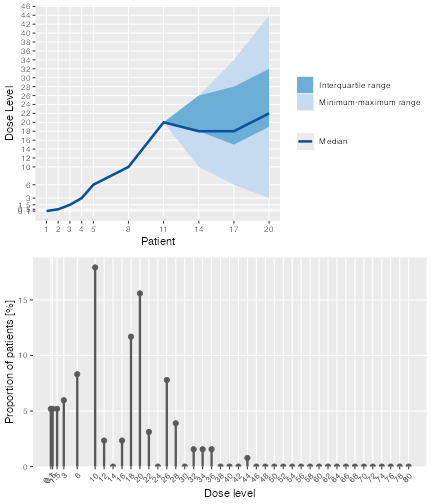

```r
print(plot(futureSims))
```

In the summary, we do not need to look at the characteristics involving the true dose-toxicity function, because in this case we are not intending to compare the performance of our CRM relative to a truth:

```r
summary(futureSims,
  truth = myTruth
)
```

```
#> Summary of 20 simulations
#>
#> Target toxicity interval was 20, 35 %
#> Target dose interval corresponding to this was 19.6, 21.6
#> Intervals are corresponding to 10 and 90 % quantiles
#>
#> Number of patients overall : mean 19 (17, 20)
#> Number of patients treated above target tox interval : mean 4 (0, 9)
#> Proportions of DLTs in the trials : mean 22 % (10 %, 31 %)
#> Mean toxicity risks for the patients on active : mean 20 % (5 %, 41 %)
#> Doses selected as MTD : mean 22.4 (9.6, 38.4)
#> True toxicity at doses selected : mean 40 % (0 %, 98 %)
#> Proportion of trials selecting target MTD: 10 %
#> Dose most often selected as MTD: 16
#> Observed toxicity rate at dose most often selected: 11 %
#> Fitted toxicity rate at dose most often selected : mean 23 % (11 %, 36 %)
#> Overdose probability at selected dose : mean 20 % (16 %, 23 %)
#> Stop reason triggered:
#>  ≥ 3 cohorts dosed :  100 %
#>  P(0.2 ≤ prob(DLE | NBD) ≤ 0.35) ≥ 0.5 :  80 %
#>  ≥ 20 patients dosed :  75 %
```

We see here e.g. that the estimated number of patients overall is 19, so 11 more than the current 8 patients are expected to be needed before finishing the trial.

# 10 Simulating 3+3 design outcomes

While `crmPack` focuses on model-based dose-escalation designs, it also includes the 3+3 design in order to allow for convenient comparisons. Note that actually no simulations would be required for the 3+3 design, because all possible outcomes can be enumerated, however we still rely here on simulations for consistency with the overall `crmPack` design.

The easiest way to setup a 3+3 design is the function `ThreePlusThreeDesign`:

```r
threeDesign <- ThreePlusThreeDesign(doseGrid = c(5, 10, 15, 25, 35, 50, 80))
class(threeDesign)
```

```
#> [1] "RuleDesign"
#> attr(,"package")
#> [1] "crmPack"
```

We have used here a much coarser dose grid than for the model-based design before, because the 3+3 design cannot jump over doses. The starting dose is automatically chosen as the first dose from the grid. The outcome is a `RuleDesign` object, and you have more setup options if you directly use the `RuleDesign()` initialization function. We can then simulate trials, again assuming that the `myTruth` function gives the true dose-toxicity relationship:

```r
threeSims <- simulate(threeDesign,
  nsim = 1000,
  seed = 35,
  truth = myTruth,
  parallel = FALSE
)
```

As before for the model-based design, we can summarize the simulations:

```r
threeSimsSum <- summary(threeSims,
  truth = myTruth
)
threeSimsSum
```

```
#> Summary of 1000 simulations
#>
#> Target toxicity interval was 20, 35 %
#> Target dose interval corresponding to this was 19.6, 21.6
#> Intervals are corresponding to 10 and 90 % quantiles
#>
#> Number of patients overall : mean 16 (15, 18)
#> Number of patients treated above target tox interval : mean 4 (3, 6)
#> Proportions of DLTs in the trials : mean 17 % (13 %, 22 %)
#> Mean toxicity risks for the patients on active : mean 17 % (14 %, 22 %)
#> Doses selected as MTD : mean 15.2 (15, 15)
#> True toxicity at doses selected : mean 4 % (3 %, 3 %)
#> Proportion of trials selecting target MTD: 0 %
#> Dose most often selected as MTD: 15
#> Observed toxicity rate at dose most often selected: 3 %
```

Here we see that 15 mg was the dose most often selected as MTD, and this is actually too low when comparing with the narrow target dose interval going from 19.6 to 21.6 mg. This is an inherent problem of dose-escalation designs where the dose grid has to be coarse: you might not know before starting the trial which is the range where you need a more refined dose grid. In this case we obtain doses that are too low, as one can see from the average true toxicity of 4~% at doses selected. Graphical summaries are again obtained by calling `plot` on the summary object:

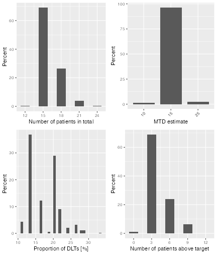

```r
print(plot(threeSimsSum))
```

# 11 Dual-endpoint dose escalation designs

In this section, we will look into dose-escalation procedures included in this package where two end points are incorporated into the study. The first endpoint is the binary DLT response that we discussed already in the last sections. The second endpoint is the continuous biomarker/efficacy response. In this package, we can either model these two responses jointly (using a single model class, assuming correlation) or separately (using two separate model classes, assuming no correlation).

Now we will first describe how we model the two responses jointly.